# An Introduction to Statistical Learning (2013)

### (c)

Create a plot displaying the univariate regression coefficients from part (a) on the x-axis, and the multiple regression coefficients from part (b) on the y-axis:

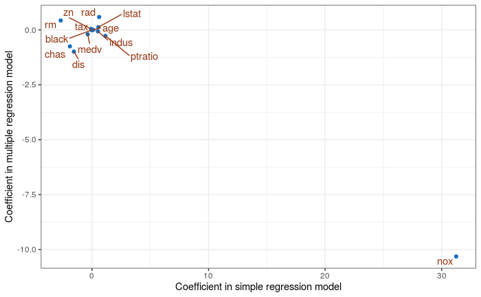

```r
mods_coefs <- map_dbl(mods, ~.$coefficients[2, 1])
mod2_coefs <- coef(mod2)[-1]

data.frame(x = mods_coefs,
       y = mod2_coefs,
       var = names(mods_coefs)) %>%
  ggplot(aes(x, y)) +
  geom_point(color = ISLR_blue) +
  ggrepel::geom_text_repel(aes(label = var),
                           color = ISLR_brown) +
  labs(x = "Coefficient in simple regression model", y = "Coefficient in multiple regression model")
```

The predictor `nox` is an outlier and makes the plot hard to read. Remove `nox` and create the plot again:

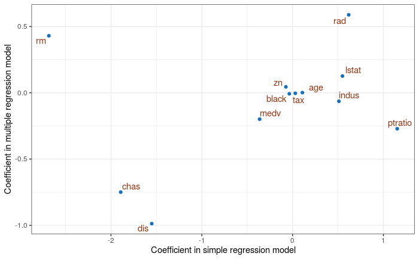

```r
mods_coefs <- map_dbl(mods, ~.$coefficients[2, 1])
mod2_coefs <- coef(mod2)[-1]

tibble(x = mods_coefs[-4],
       y = mod2_coefs[-4],
       var = names(mods_coefs[-4])) %>%
  ggplot(aes(x, y)) +
  geom_point(color = ISLR_blue) +
  ggrepel::geom_text_repel(aes(label = var),
                           color = ISLR_brown) +
  labs(x = "Coefficient in simple regression model", y = "Coefficient in multiple regression model")
```

It is not surprising to see that the coefficients have changed in value and even sign in some cases. In a simple model the coefficient is the average change in the response from a unit change in the predictor without consideration of the other predictors. In the multiple model, the coefficient is the average change in the response from a unit change in the predictor while holding the other predictors fixed. Because of possible correlations and collinearities between predictors it is possible that the coefficients will have different values and even signs in different models.

### (d)

```r
mods3 <- Boston %>%
  dplyr::select(-crim, -chas) %>%
  map(function(var) summary(lm(crim ~ poly(var, 3), data = Boston)))
```

View p-values for the linear terms:

```r
p.values3 <- map_dbl(mods3, ~.$coefficients[2, 4])
p.values3
```

```
          zn        indus          nox           rm          age          dis          rad          tax      ptratio        black
4.697806e-06 8.854243e-24 2.457491e-26 5.128048e-07 4.878803e-17 1.253249e-21 1.053211e-56 6.976314e-49 1.565484e-11 2.730082e-19
       lstat         medv
1.678072e-27 4.930818e-27
```

The p-value for the single predictor’s linear term is significant for the below predictors:

```r
p.values3[p.values3 < 0.05]
```

```
          zn        indus          nox           rm          age          dis          rad          tax      ptratio        black
4.697806e-06 8.854243e-24 2.457491e-26 5.128048e-07 4.878803e-17 1.253249e-21 1.053211e-56 6.976314e-49 1.565484e-11 2.730082e-19
       lstat         medv
1.678072e-27 4.930818e-27
```

View p-values for the quadratic terms:

```r
p.values3_quad <- map_dbl(mods3, ~.$coefficients[3, 4])
p.values3_quad
```

```
          zn        indus          nox           rm          age          dis          rad          tax      ptratio        black
4.420507e-03 1.086057e-03 7.736755e-05 1.508545e-03 2.291156e-06 7.869767e-14 9.120558e-03 3.665348e-06 2.405468e-03 4.566044e-01
       lstat         medv
3.780418e-02 2.928577e-35
```

The p-value for the single predictor’s quadratic term is significant for the below predictors:

```r
p.values3_quad[p.values3_quad < 0.05]
```

```
          zn        indus          nox           rm          age          dis          rad          tax      ptratio        lstat
4.420507e-03 1.086057e-03 7.736755e-05 1.508545e-03 2.291156e-06 7.869767e-14 9.120558e-03 3.665348e-06 2.405468e-03 3.780418e-02
        medv
2.928577e-35
```

View p-values for the cubic terms:

```r
p.values3_cubic <- map_dbl(mods3, ~.$coefficients[4, 4])
p.values3_cubic
```

```
          zn        indus          nox           rm          age          dis          rad          tax      ptratio        black
2.295386e-01 1.196405e-12 6.961110e-16 5.085751e-01 6.679915e-03 1.088832e-08 4.823138e-01 2.438507e-01 6.300514e-03 5.436172e-01
       lstat         medv
1.298906e-01 1.046510e-12
```

The p-value for the single predictor’s cubic term is significant for the below predictors:

```r
p.values3_cubic[p.values3_cubic < 0.05]
```

```
       indus          nox          age          dis      ptratio         medv
1.196405e-12 6.961110e-16 6.679915e-03 1.088832e-08 6.300514e-03 1.046510e-12
```

The p-value for the single predictor’s quadratic **AND** cubic term is significant for the below predictors:

```r
p.values3_quad[(p.values3_quad < 0.05) & (p.values3_cubic < 0.05)] %>% names()
```

```
[1] "indus"   "nox"     "age"     "dis"     "ptratio" "medv"
```

The p-value for the neither of single predictor’s quadratic **OR** cubic term is significant for the below predictors (i.e. there is no evidence of non-linearity):

```r
p.values3_quad[(p.values3_quad > 0.05) & (p.values3_cubic > 0.05)] %>% names()
```

```
[1] "black"
```

[^1]: James G, Witten D, Hastie T, Tibshirani R (2013). *An Introduction to Statistical Learning: with Applications in R*. Springer, 1st edition.